# SFINCS

**Author:** Salvador Navas  
**Model:** SFINCS (Super-Fast INundation of CoastS) — Deltares  
**Sources:** [SFINCS docs](https://sfincs.readthedocs.io) · hydromt_sfincs · [Deltares GitHub](https://github.com/Deltares/SFINCS)

### SFINCS — Automated flood modelling with `pyhydra` + `hydromt_sfincs`

SFINCS is an open-source reduced-complexity 2D flood model (overland + coastal).  
`hydromt_sfincs` is the Deltares Python interface for building, running and post-processing SFINCS models.

**Install:**

```
pip install hydromt_sfincs xarray rasterio
# SFINCS binary (Linux): conda install -c conda-forge sfincs
```

**Key role in HYDRA** — hybrid downscaling requires running **many hydraulic simulations** (one per climate-change scenario × return period). The automation here (`setup_sfincs_model`, `run_sfincs`) is designed to be called inside a loop over the ensemble.

Workflow:

1. Build a fluvial flood-plain domain with a synthetic DEM
2. Inspect model structure with hydromt_sfincs
3. Define the T100 design hydrograph as discharge BC
4. Write and run SFINCS (binary via `pyhydra.modeling.hydraulic.sfincs`)
5. Post-process: flood depth, extent, volume
6. Climate-change ensemble — discharge scaling across CMIP6 scenarios

## 1. Build a synthetic fluvial floodplain domain

```
✓ Base SFINCS model written → /workspace/data/sfincs/base_model
  Grid : 120 × 80 cells  (50.0 m resolution)
  Size : 6.0 km × 4.0 km
  CRS  : EPSG:32630
```

## 2. Inspect model structure with hydromt_sfincs

```
Grid dims : FrozenMappingWarningOnValuesAccess({'y': 80, 'x': 120})
Grid vars : ['msk', 'dep']
Config:
  tref       = 2024-01-01 00:00:00
  tstart     = 2024-01-01 00:00:00
  tstop      = 2024-01-03 00:00:00
  dx         = 50.0
  dy         = 50.0
  epsg       = 32630
  dtmax      = 30
```

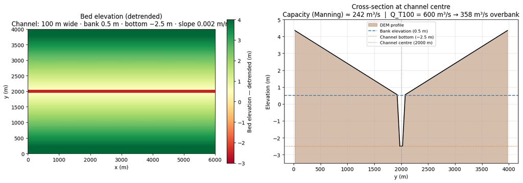

## 3. T100 design flood hydrograph

```
Duration   : 48 h  (576 steps × 5 min)
Peak flow  : 600 m³/s  at t = 12 h
Volume     : 63.91 Mm³
```

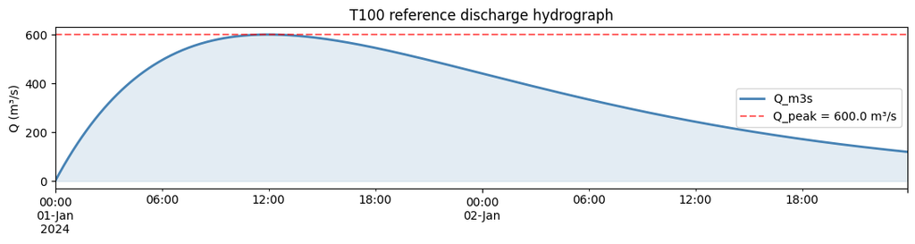

## 4. Configure model: discharge + output + Manning roughness

`pyhydra.modeling.hydraulic.sfincs.setup_sfincs_model` configures a complete SFINCS run directory from a basin polygon, DEM and discharge time series.  
Here we use the synthetic domain built above. For real catchments, pass the actual basin GeoDataFrame and DEM GeoTIFF.

```
  src: 1 points, dis: 576 time steps
✓ SFINCS model set up → /workspace/data/sfincs/run_T100
  WL boundary: 80 pts at x=5975 m · WL_max=2.75 m
✓ T100 run directory ready → /workspace/data/sfincs/run_T100
```

## 5. SFINCS execution — Docker (from host) and analytical validation

SFINCS runs as a standalone binary compiled for `linux/amd64`. Inside the Jupyter container (also `linux/amd64`) there is no Docker socket, so the binary is invoked from the **host machine**:

```
# Run T100 simulation — execute from the host terminal:
docker run --rm --platform=linux/amd64 \
    -v <path-to-HYDRA>/data/sfincs/run_T100:/data \
    deltares/sfincs-cpu:latest
```

The downstream boundary is prescribed as a **water-level time series** (Manning's normal depth for each Q(t) of the hydrograph), written automatically to `sfincs.bnd` + `sfincs.bzs` during model setup. This gives a **rating-curve exit condition** and allows the 2D flood to develop across the floodplain.

Results are stored in `sfincs_map.nc`. The cell below reads the pre-computed output and compares it against Manning's analytical steady-state solution.

```
── Manning analytical (T100) ──
  Channel  : W=100 m · zb=-2.5 m · bank=0.5 m
  Full-bank: 243 m³/s  (S=2e-04, n=0.035)
  T100     : Q=600 m³/s → yn=5.25 m → WSEL=2.75 m

  Manning flood area : 12.60 km²  (uniform steady flow)

── SFINCS 2D (dynamic routing) ──
  HOST command (run before this notebook):
    docker run --rm --platform=linux/amd64 \
      -v /workspace/data/sfincs/run_T100:/data deltares/sfincs-cpu:latest

  SFINCS flood area : 8.39 km²  (dynamic 48 h simulation)
  Max flood depth   : 5.24 m

  Comparison — Manning (steady) vs. SFINCS (dynamic):
    Manning : 12.60 km²  → equilibrium upper bound
    SFINCS  : 8.39 km²  → dynamic routing (WL boundary = Manning rating curve)
    Ratio   : 0.67  (dynamic routing < steady: incomplete flood development during 48h)
```

## 6. Post-process: flood maps — SFINCS 2D vs. Manning reference

Three-panel map:

| Panel | Content |
| --- | --- |
| 1 — DEM | Detrended bed elevation (longitudinal slope removed) |
| 2 — SFINCS | Peak flood depth from `sfincs_map.nc` (dynamic 2D routing) |
| 3 — Manning | Steady-state normal depth (analytical upper bound) |

The difference between SFINCS and Manning reflects the **transient flood wave**: Manning assumes the entire channel has reached uniform flow simultaneously, while SFINCS resolves the actual propagation upstream from the WL boundary.

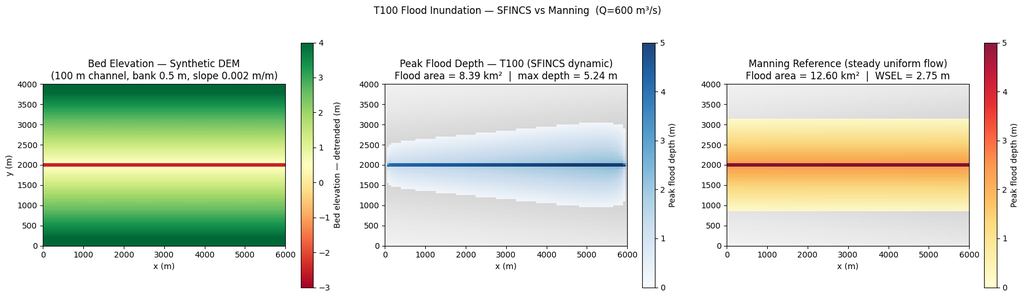

## 7. Climate-change ensemble — automated multi-simulation loop

This is the **core workflow for hybrid downscaling**: each GCM-RCM scenario produces a discharge delta factor from the hydrological model (HEC-HMS / SWAT+), which is applied to the reference hydrograph and fed into SFINCS.

The loop below:

1. Scales the T100 hydrograph by the CC delta factor
2. Calls `setup_sfincs_model` to write a new run directory
3. Calls `run_sfincs` to execute the binary
4. Reads `sfincs_map.nc` and extracts flood area + max depth

In practice, `delta_factors` come from the climate-change runs in the  
HEC_HMS or SWAT notebooks (ratio of future-to-reference peak discharge per scenario).

```
To run all CC scenarios from the host terminal:
  docker run --rm --platform=linux/amd64 -v /workspace/data/sfincs/run_MIROC6_ssp245_NF:/data deltares/sfincs-cpu:latest
  docker run --rm --platform=linux/amd64 -v /workspace/data/sfincs/run_MIROC6_ssp585_NF:/data deltares/sfincs-cpu:latest
  docker run --rm --platform=linux/amd64 -v /workspace/data/sfincs/run_MPI-ESM1-2-LR_ssp245_NF:/data deltares/sfincs-cpu:latest
  docker run --rm --platform=linux/amd64 -v /workspace/data/sfincs/run_MPI-ESM1-2-LR_ssp585_NF:/data deltares/sfincs-cpu:latest
  docker run --rm --platform=linux/amd64 -v /workspace/data/sfincs/run_CNRM-CM6-1_ssp245_NF:/data deltares/sfincs-cpu:latest
  docker run --rm --platform=linux/amd64 -v /workspace/data/sfincs/run_CNRM-CM6-1_ssp585_MF:/data deltares/sfincs-cpu:latest
  docker run --rm --platform=linux/amd64 -v /workspace/data/sfincs/run_ACCESS-CM2_ssp245_NF:/data deltares/sfincs-cpu:latest
  docker run --rm --platform=linux/amd64 -v /workspace/data/sfincs/run_ACCESS-CM2_ssp585_MF:/data deltares/sfincs-cpu:latest
  docker run --rm --platform=linux/amd64 -v /workspace/data/sfincs/run_MRI-ESM2-0_ssp585_FF:/data deltares/sfincs-cpu:latest

  src: 1 points, dis: 576 time steps
✓ SFINCS model set up → /workspace/data/sfincs/run_MIROC6_ssp245_NF
  WL boundary: 80 pts at x=5975 m · WL_max=2.95 m
  MIROC6_ssp245_NF                     δ=1.06  area=9.49 km²  max=5.43 m  [SFINCS]
  src: 1 points, dis: 576 time steps
✓ SFINCS model set up → /workspace/data/sfincs/run_MIROC6_ssp585_NF
  WL boundary: 80 pts at x=5975 m · WL_max=3.14 m
  MIROC6_ssp585_NF                     δ=1.12  area=10.60 km²  max=5.62 m  [SFINCS]
  src: 1 points, dis: 576 time steps
✓ SFINCS model set up → /workspace/data/sfincs/run_MPI-ESM1-2-LR_ssp245_NF
  WL boundary: 80 pts at x=5975 m · WL_max=2.65 m
  MPI-ESM1-2-LR_ssp245_NF              δ=0.97  area=7.82 km²  max=5.14 m  [SFINCS]
  src: 1 points, dis: 576 time steps
✓ SFINCS model set up → /workspace/data/sfincs/run_MPI-ESM1-2-LR_ssp585_NF
  WL boundary: 80 pts at x=5975 m · WL_max=2.88 m
  MPI-ESM1-2-LR_ssp585_NF              δ=1.04  area=9.14 km²  max=5.37 m  [SFINCS]
  src: 1 points, dis: 576 time steps
✓ SFINCS model set up → /workspace/data/sfincs/run_CNRM-CM6-1_ssp245_NF
  WL boundary: 80 pts at x=5975 m · WL_max=3.01 m
  CNRM-CM6-1_ssp245_NF                 δ=1.08  area=9.87 km²  max=5.50 m  [SFINCS]
  src: 1 points, dis: 576 time steps
✓ SFINCS model set up → /workspace/data/sfincs/run_CNRM-CM6-1_ssp585_MF
  WL boundary: 80 pts at x=5975 m · WL_max=3.32 m
  CNRM-CM6-1_ssp585_MF                 δ=1.18  area=11.66 km²  max=5.81 m  [SFINCS]
  src: 1 points, dis: 576 time steps
✓ SFINCS model set up → /workspace/data/sfincs/run_ACCESS-CM2_ssp245_NF
  WL boundary: 80 pts at x=5975 m · WL_max=2.85 m
  ACCESS-CM2_ssp245_NF                 δ=1.03  area=8.92 km²  max=5.34 m  [SFINCS]
  src: 1 points, dis: 576 time steps
✓ SFINCS model set up → /workspace/data/sfincs/run_ACCESS-CM2_ssp585_MF
  WL boundary: 80 pts at x=5975 m · WL_max=3.04 m
  ACCESS-CM2_ssp585_MF                 δ=1.09  area=10.03 km²  max=5.53 m  [SFINCS]
  src: 1 points, dis: 576 time steps
✓ SFINCS model set up → /workspace/data/sfincs/run_MRI-ESM2-0_ssp585_FF
  WL boundary: 80 pts at x=5975 m · WL_max=3.45 m
  MRI-ESM2-0_ssp585_FF                 δ=1.22  area=12.36 km²  max=5.93 m  [SFINCS]

9 scenarios completed.
```

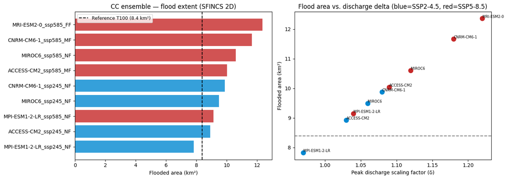